# COM747 Week 9: Association Rule Mining

Lecture demonstrations and complete seminar solutions

> **How to use this notebook.** Part A computes support, confidence and lift by hand on a tiny shop so the formulas are concrete, and shows the apriori pruning idea. Part B is the complete seminar exercise on the `Groceries` data (`Exercise(6).pdf` / `exercise(2).pptx`), with every step answered. Part C is extra practice. The data is built into `arules`, so no files are needed.

```r
library(arules)       # transactions, apriori(), inspect()
library(arulesViz)    # plot() methods for rules
```

# Part A: The measures by hand

## A1. The lecture example (3 baskets)

```r
baskets <- list(
  c("milk", "bread", "eggs", "apples", "grapes"),
  c("carrots", "peas", "potatoes"),
  c("carrots", "peas", "potatoes", "milk", "bread", "eggs"))
trans <- as(baskets, "transactions")    # convert a list of baskets to the arules class
inspect(trans)
```

```
##     items
## [1] {apples, bread, eggs, grapes, milk}
## [2] {carrots, peas, potatoes}
## [3] {bread, carrots, eggs, milk, peas, potatoes}
```

```r
as(trans, "matrix") * 1                 # the 0/1 basket-by-item matrix behind it
```

```
##      apples bread carrots eggs grapes milk peas potatoes
## [1,]      1     1       0    1      1    1    0        0
## [2,]      0     0       1    0      0    0    1        1
## [3,]      0     1       1    1      0    1    1        1
```

```r
N <- length(trans)
has <- function(item) sapply(baskets, function(b) all(item %in% b))   # TRUE if basket contains every item

support    <- function(items) sum(has(items)) / N
confidence <- function(lhs, rhs) support(c(lhs, rhs)) / support(lhs)
lift       <- function(lhs, rhs) confidence(lhs, rhs) / support(rhs)

support("milk")                    # 2/3: as on the slide
```

```
## [1] 0.6666667
```

```r
support(c("milk", "bread"))        # 2/3: the support of the rule {milk} => {bread}
```

```
## [1] 0.6666667
```

```r
confidence("milk", "bread")        # 1: every basket with milk has bread
```

```
## [1] 1
```

```r
lift("milk", "bread")              # 1 / (2/3) = 1.5
```

```
## [1] 1.5
```

**Ask (slide question):** which items should the algorithm ignore? Apples and grapes appear in only one basket of three, so with a minimum support of, say, 0.5 they can be dropped before any pairs are considered.

## A2. Check with `apriori()`

```r
r <- apriori(trans, parameter = list(support = 0.5, confidence = 0.5, minlen = 2),
             control = list(verbose = FALSE))
inspect(subset(r, lhs %in% "milk" & rhs %in% "bread"))   # support 0.67, confidence 1, lift 1.5
```

```
##     lhs             rhs     support   confidence coverage  lift count
## [1] {milk}       => {bread} 0.6666667 1          0.6666667 1.5  2
## [2] {eggs, milk} => {bread} 0.6666667 1          0.6666667 1.5  2
```

## A3. Why lift matters: a 10-basket shop

```r
shop <- list(c("bread","milk","eggs"), c("bread","butter"), c("milk","nappies","beer"),
             c("bread","milk","butter"), c("bread","milk","eggs","butter"), c("beer","nappies"),
             c("milk","eggs"), c("bread","milk","beer","nappies"), c("bread","eggs","butter"),
             c("milk","nappies","beer"))
shopT <- as(shop, "transactions")
itemFrequency(shopT)                     # milk is in 7 of 10 baskets
```

```
##    beer   bread  butter    eggs    milk nappies
##     0.4     0.6     0.4     0.4     0.7     0.4
```

```r
shopRules <- apriori(shopT, parameter = list(support = 0.2, confidence = 0.5, minlen = 2),
                     control = list(verbose = FALSE))
inspect(sort(shopRules, by = "lift")[1:5])
```

```
##     lhs                rhs       support confidence coverage lift     count
## [1] {beer}          => {nappies} 0.4     1          0.4      2.500000 4
## [2] {nappies}       => {beer}    0.4     1          0.4      2.500000 4
## [3] {beer, milk}    => {nappies} 0.3     1          0.3      2.500000 3
## [4] {milk, nappies} => {beer}    0.3     1          0.3      2.500000 3
## [5] {butter}        => {bread}   0.4     1          0.4      1.666667 4
```

```r
inspect(subset(shopRules, rhs %in% "milk"))
```

```
##     lhs                rhs    support confidence coverage lift      count
## [1] {eggs}          => {milk} 0.3     0.7500000  0.4      1.0714286 3
## [2] {butter}        => {milk} 0.2     0.5000000  0.4      0.7142857 2
## [3] {beer}          => {milk} 0.3     0.7500000  0.4      1.0714286 3
## [4] {nappies}       => {milk} 0.3     0.7500000  0.4      1.0714286 3
## [5] {bread}         => {milk} 0.4     0.6666667  0.6      0.9523810 4
## [6] {bread, eggs}   => {milk} 0.2     0.6666667  0.3      0.9523810 2
## [7] {bread, butter} => {milk} 0.2     0.5000000  0.4      0.7142857 2
## [8] {beer, nappies} => {milk} 0.3     0.7500000  0.4      1.0714286 3
```

**Ask:** {eggs} ⇒ {milk} has confidence 0.75. Is that a good rule? Milk is in 70% of all baskets anyway, so lift is only 0.75 / 0.7 ≈ 1.07: eggs tell us almost nothing about milk. {nappies} ⇒ {beer} has lift 2.5.

## A4. The combinatorial explosion and the apriori property

```r
k <- c(5, 10, 20, 50, 100, 169)
data.frame(items = k, possible_itemsets = format(2^k, scientific = TRUE, digits = 4))
```

```
##   items possible_itemsets
## 1     5         3.200e+01
## 2    10         1.024e+03
## 3    20         1.049e+06
## 4    50         1.126e+15
## 5   100         1.268e+30
## 6   169         7.483e+50
```

```r
2^100                                    # 1.267651e+30, as on the slide
```

```
## [1] 1.267651e+30
```

The apriori property: *every subset of a frequent itemset must also be frequent*. So candidates of size k are only built from frequent itemsets of size k − 1. Here is the level-by-level search written out for the 10-basket shop with a minimum count of 3:

```r
items <- itemLabels(shopT)
count <- function(s) sum(sapply(shop, function(b) all(s %in% b)))
min_count <- 3

level <- lapply(items, identity)            # level 1: every single item
k <- 1
while (length(level) > 0) {
  counts   <- sapply(level, count)
  frequent <- level[counts >= min_count]
  cat("Level", k, ": counted", length(level), "candidates,", length(frequent), "frequent\n")
  if (length(frequent) > 0) print(sapply(frequent, paste, collapse = ","))
  if (length(frequent) < 2) break           # nothing left to combine
  # build size k+1 candidates from frequent itemsets, keeping only those whose
  # every size-k subset is frequent (the apriori pruning step)
  cand <- unique(lapply(combn(length(frequent), 2, simplify = FALSE),
                        function(ij) sort(unique(c(frequent[[ij[1]]], frequent[[ij[2]]])))))
  cand <- Filter(function(s) length(s) == k + 1, cand)
  key  <- sapply(frequent, paste, collapse = ",")
  cand <- Filter(function(s) all(combn(s, k, paste, collapse = ",") %in% key), cand)
  level <- cand; k <- k + 1
}
```

```
## Level 1 : counted 6 candidates, 6 frequent
## [1] "beer"    "bread"   "butter"  "eggs"    "milk"    "nappies"
## Level 2 : counted 15 candidates, 7 frequent
## [1] "beer,milk"    "beer,nappies" "bread,butter" "bread,eggs"   "bread,milk"
## [6] "eggs,milk"    "milk,nappies"
## Level 3 : counted 2 candidates, 1 frequent
## [1] "beer,milk,nappies"
```

# Part B: Seminar exercise with Groceries

## B1. Load the data and summarise

```r
data("Groceries")
Groceries                  # transactions in sparse format with 9835 transactions and 169 items
```

```
## transactions in sparse format with
##  9835 transactions (rows) and
##  169 items (columns)
```

```r
summary(Groceries)
```

```
## transactions as itemMatrix in sparse format with
##  9835 rows (elements/itemsets/transactions) and
##  169 columns (items) and a density of 0.02609146
##
## most frequent items:
##       whole milk other vegetables       rolls/buns             soda
##             2513             1903             1809             1715
##           yogurt          (Other)
##             1372            34055
##
## element (itemset/transaction) length distribution:
## sizes
##    1    2    3    4    5    6    7    8    9   10   11   12   13   14   15   16
## 2159 1643 1299 1005  855  645  545  438  350  246  182  117   78   77   55   46
##   17   18   19   20   21   22   23   24   26   27   28   29   32
##   29   14   14    9   11    4    6    1    1    1    1    3    1
##
##    Min. 1st Qu.  Median    Mean 3rd Qu.    Max.
##   1.000   2.000   3.000   4.409   6.000  32.000
##
## includes extended item information - examples:
##        labels  level2           level1
## 1 frankfurter sausage meat and sausage
## 2     sausage sausage meat and sausage
## 3  liver loaf sausage meat and sausage
```

Reading the summary:

- **9835 rows (transactions) and 169 columns (items)**; density 0.026 means 2.6% of cells are 1.
- **Most frequent items**: whole milk 2513, other vegetables 1903, rolls/buns 1809, soda 1715, yogurt 1372.
- **Element length distribution**: 2159 baskets have a single item; the mean basket has 4.4 items, the largest 32.

## B2. Check the support of the top 5 items

Support is how often an item occurs: count / number of transactions.

```r
top5_counts <- c("whole milk" = 2513, "other vegetables" = 1903, "rolls/buns" = 1809,
                 "soda" = 1715, "yogurt" = 1372)
round(top5_counts / length(Groceries), 4)                       # by hand
```

```
##       whole milk other vegetables       rolls/buns             soda
##           0.2555           0.1935           0.1839           0.1744
##           yogurt
##           0.1395
```

```r
round(sort(itemFrequency(Groceries), decreasing = TRUE)[1:5], 4) # arules agrees
```

```
##       whole milk other vegetables       rolls/buns             soda
##           0.2555           0.1935           0.1839           0.1744
##           yogurt
##           0.1395
```

```r
sort(itemFrequency(Groceries, type = "absolute"), decreasing = TRUE)[1:5]   # the counts
```

```
##       whole milk other vegetables       rolls/buns             soda
##             2513             1903             1809             1715
##           yogurt
##             1372
```

## B3. Item frequency plots

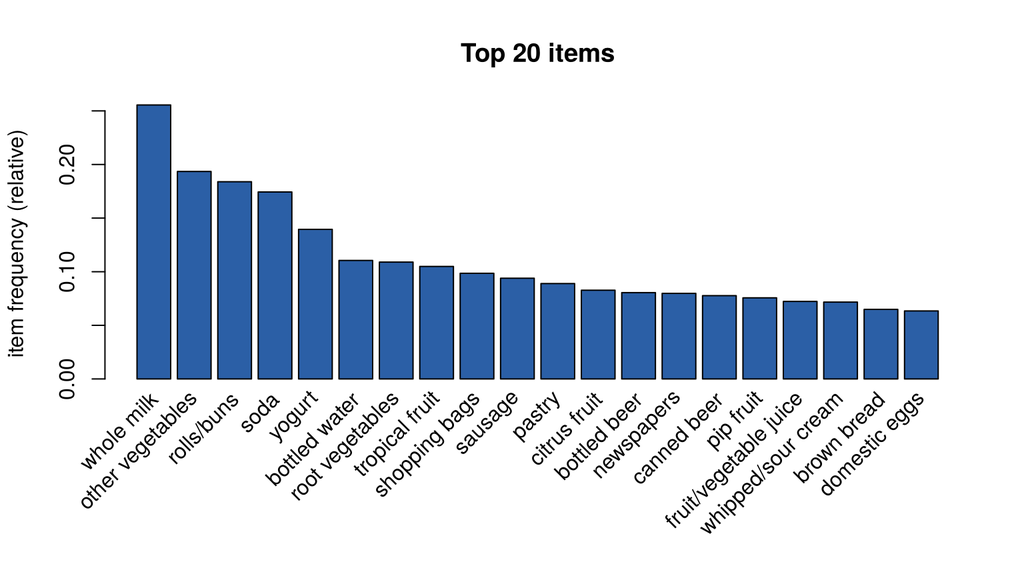

```r
itemFrequencyPlot(Groceries, topN = 20, col = "#2b5fa6", main = "Top 20 items")
```

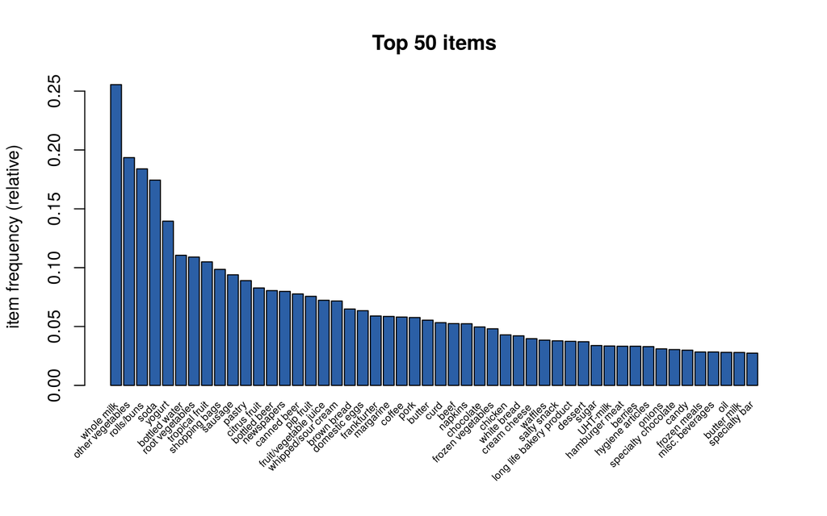

```r
itemFrequencyPlot(Groceries, topN = 50, cex.names = 0.6, col = "#2b5fa6", main = "Top 50 items")
```

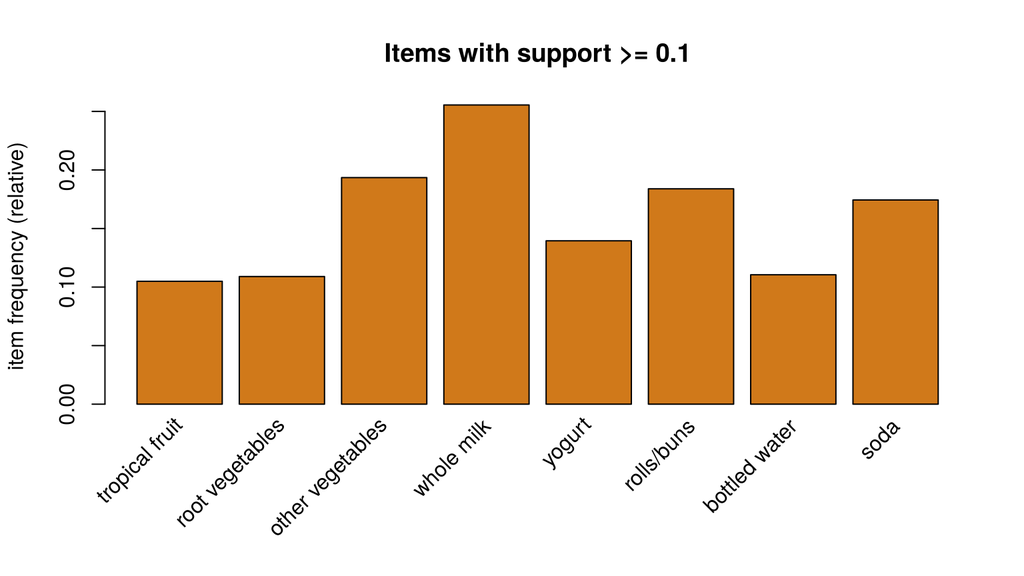

```r
itemFrequencyPlot(Groceries, support = 0.1, col = "#d0791a", main = "Items with support >= 0.1")
```

```r
sum(itemFrequency(Groceries) >= 0.1)          # 8 items
```

```
## [1] 8
```

`?itemFrequencyPlot` shows more options, for example `type = "absolute"` for counts instead of proportions:

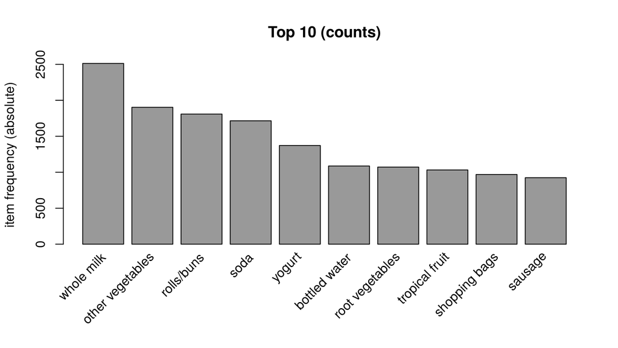

```r
itemFrequencyPlot(Groceries, topN = 10, type = "absolute", col = "grey60", main = "Top 10 (counts)")
```

## B4. Sparsity

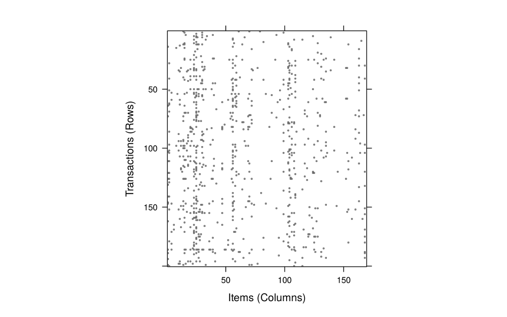

```r
image(Groceries[1:200])       # rows = first 200 transactions, columns = 169 items
```

Almost everything is white: each basket holds a handful of the 169 items. The vertical streaks are the popular items (whole milk, other vegetables…). A random sample is a fairer picture than the first 200 rows:

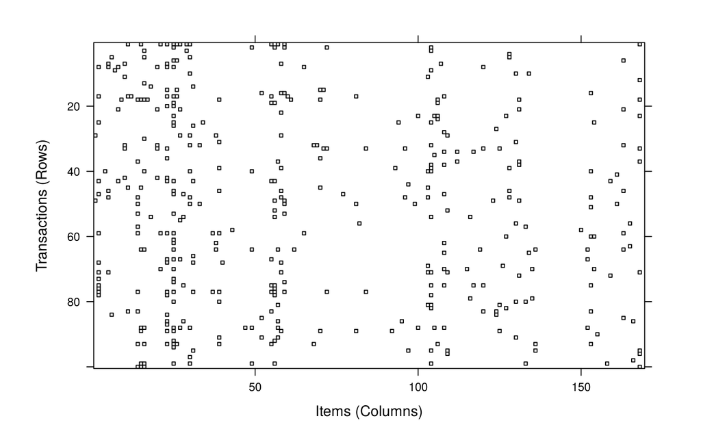

```r
set.seed(1)
image(sample(Groceries, 100))
```

## B5. Run apriori

```r
rules <- apriori(Groceries, parameter = list(support = 0.001, confidence = 0.25, minlen = 2))
```

```
## Apriori
##
## Parameter specification:
##  confidence minval smax arem  aval originalSupport maxtime support minlen
##        0.25    0.1    1 none FALSE            TRUE       5   0.001      2
##  maxlen target  ext
##      10  rules TRUE
##
## Algorithmic control:
##  filter tree heap memopt load sort verbose
##     0.1 TRUE TRUE  FALSE TRUE    2    TRUE
##
## Absolute minimum support count: 9
##
## set item appearances ...[0 item(s)] done [0.00s].
## set transactions ...[169 item(s), 9835 transaction(s)] done [0.00s].
## sorting and recoding items ... [157 item(s)] done [0.00s].
## creating transaction tree ... done [0.00s].
## checking subsets of size 1 2 3 4 5 6 done [0.01s].
## writing ... [17391 rule(s)] done [0.00s].
## creating S4 object  ... done [0.00s].
```

```r
rules
```

```
## set of 17391 rules
```

- `support = 0.001`: an itemset must appear in at least 0.1% of baskets (≈ 10 baskets).
- `confidence = 0.25`: the rule must be right at least 25% of the time.
- `minlen = 2`: at least two items in the rule, so no empty-LHS rules like `{} => {whole milk}`.

Different limits give very different numbers of rules:

```r
grid <- expand.grid(support = c(0.001, 0.005, 0.01), confidence = c(0.25, 0.5))
grid$rules <- mapply(function(s, c) length(apriori(Groceries,
  parameter = list(support = s, confidence = c, minlen = 2), control = list(verbose = FALSE))),
  grid$support, grid$confidence)
grid
```

```
##   support confidence rules
## 1   0.001       0.25 17391
## 2   0.005       0.25   662
## 3   0.010       0.25   170
## 4   0.001       0.50  5668
## 5   0.005       0.50   120
## 6   0.010       0.50    15
```

## B6. Inspect the first 20 rules

```r
inspect(rules[1:20])
```

```
##      lhs                    rhs                support     confidence
## [1]  {honey}             => {whole milk}       0.001118454 0.7333333
## [2]  {soap}              => {whole milk}       0.001118454 0.4230769
## [3]  {tidbits}           => {soda}             0.001016777 0.4347826
## [4]  {tidbits}           => {rolls/buns}       0.001220132 0.5217391
## [5]  {cocoa drinks}      => {whole milk}       0.001321810 0.5909091
## [6]  {snack products}    => {soda}             0.001118454 0.3666667
## [7]  {snack products}    => {rolls/buns}       0.001118454 0.3666667
## [8]  {pudding powder}    => {whole milk}       0.001321810 0.5652174
## [9]  {cooking chocolate} => {whole milk}       0.001321810 0.5200000
## [10] {bathroom cleaner}  => {soda}             0.001016777 0.3703704
## [11] {bathroom cleaner}  => {other vegetables} 0.001016777 0.3703704
## [12] {nuts/prunes}       => {rolls/buns}       0.001016777 0.3030303
## [13] {nuts/prunes}       => {whole milk}       0.001220132 0.3636364
## [14] {brandy}            => {shopping bags}    0.001321810 0.3170732
```

[output cut: 27 more lines]

Assessing them: most are 2-item rules with tiny support (10 to 13 baskets out of 9835), and many have a very common item (whole milk, soda, rolls/buns) on the right-hand side, which is why their confidence is fairly high. The lift column shows which are genuinely interesting: {potato products} ⇒ {pastry} (lift 4.0) and {brandy} ⇒ {shopping bags} (3.2) are stronger than {nuts/prunes} ⇒ {whole milk} (1.4).

## B7. Check the lift by hand

```r
supp_milk <- itemFrequency(Groceries)["whole milk"]
supp_milk                                 # 0.255516
```

```
## whole milk
##   0.255516
```

```r
0.7333333 / 0.255516                      # 2.870009, the slide's calculation
```

```
## [1] 2.870009
```

```r
q <- quality(rules[1])
q$confidence / supp_milk                  # same, from the rule object
```

```
## whole milk
##   2.870009
```

```r
q$lift
```

```
## [1] 2.870009
```

```r
# Check all 20 at once: lift = confidence / support(rhs)
r20 <- rules[1:20]
rhs_items <- unlist(LIST(rhs(r20)))
check <- data.frame(rule = labels(r20),
                    confidence = quality(r20)$confidence,
                    supp_rhs   = itemFrequency(Groceries)[rhs_items],
                    lift_by_hand = quality(r20)$confidence / itemFrequency(Groceries)[rhs_items],
                    lift_arules  = quality(r20)$lift, row.names = NULL)
check[, -1] <- round(check[, -1], 4)
check
```

```
##                                        rule confidence supp_rhs lift_by_hand
## 1                   {honey} => {whole milk}     0.7333   0.2555       2.8700
## 2                    {soap} => {whole milk}     0.4231   0.2555       1.6558
## 3                       {tidbits} => {soda}     0.4348   0.1744       2.4933
## 4                 {tidbits} => {rolls/buns}     0.5217   0.1839       2.8365
## 5            {cocoa drinks} => {whole milk}     0.5909   0.2555       2.3126
## 6                {snack products} => {soda}     0.3667   0.1744       2.1027
## 7          {snack products} => {rolls/buns}     0.3667   0.1839       1.9935
## 8          {pudding powder} => {whole milk}     0.5652   0.2555       2.2121
## 9       {cooking chocolate} => {whole milk}     0.5200   0.2555       2.0351
## 10             {bathroom cleaner} => {soda}     0.3704   0.1744       2.1240
## 11 {bathroom cleaner} => {other vegetables}     0.3704   0.1935       1.9141
## 12            {nuts/prunes} => {rolls/buns}     0.3030   0.1839       1.6475
## 13            {nuts/prunes} => {whole milk}     0.3636   0.2555       1.4231
## 14              {brandy} => {shopping bags}     0.3171   0.0985       3.2182
```

[output cut: 27 more lines]

```r
all.equal(check$lift_by_hand, check$lift_arules, tolerance = 1e-4)
```

```
## [1] TRUE
```

## B8. Minimum length 3

```r
rules3 <- apriori(Groceries, parameter = list(support = 0.001, confidence = 0.25, minlen = 3),
                  control = list(verbose = FALSE))
rules3                                    # 17024 rules
```

```
## set of 17024 rules
```

```r
inspect(rules3[1:10])
```

```
##      lhs                                rhs                support
## [1]  {liver loaf, yogurt}            => {whole milk}       0.001016777
## [2]  {liver loaf, whole milk}        => {yogurt}           0.001016777
## [3]  {tropical fruit, curd cheese}   => {other vegetables} 0.001016777
## [4]  {other vegetables, curd cheese} => {tropical fruit}   0.001016777
## [5]  {curd cheese, rolls/buns}       => {whole milk}       0.001016777
## [6]  {whole milk, curd cheese}       => {rolls/buns}       0.001016777
## [7]  {other vegetables, curd cheese} => {whole milk}       0.001220132
## [8]  {whole milk, curd cheese}       => {other vegetables} 0.001220132
## [9]  {other vegetables, cleaner}     => {whole milk}       0.001016777
## [10] {whole milk, cleaner}           => {other vegetables} 0.001016777
##      confidence coverage    lift     count
## [1]  0.6666667  0.001525165 2.609099 10
## [2]  0.4761905  0.002135231 3.413508 10
## [3]  0.6666667  0.001525165 3.445437 10
## [4]  0.4761905  0.002135231 4.538114 10
## [5]  0.6250000  0.001626843 2.446031 10
## [6]  0.4347826  0.002338587 2.363785 10
## [7]  0.5714286  0.002135231 2.236371 12
## [8]  0.5217391  0.002338587 2.696429 12
## [9]  0.6250000  0.001626843 2.446031 10
## [10] 0.4347826  0.002338587 2.247024 10
```

```r
table(size(rules))                        # rule sizes in the original set
```

```
##
##    2    3    4    5    6
##  367 6906 8371 1687   60
```

**Slide inconsistency:** the lecture slide headed “Min length = 3” shows `support = 0.01, confidence = 0.25, minlen = 2` (which gives 170 rules). For the exercise use `minlen = 3`, as above. Only 367 of the 17,391 rules have exactly 2 items, so `minlen = 3` removes very few.

## B9. Sort the rules by different metrics

```r
inspect(sort(rules, by = "lift")[1:10])        # rare, specific combinations
```

```
##      lhs                                     rhs                support
## [1]  {bottled beer, red/blush wine}       => {liquor}           0.001931876
## [2]  {ham, white bread}                   => {processed cheese} 0.001931876
## [3]  {bottled beer, liquor}               => {red/blush wine}   0.001931876
## [4]  {Instant food products, soda}        => {hamburger meat}   0.001220132
## [5]  {curd, sugar}                        => {flour}            0.001118454
## [6]  {sugar, baking powder}               => {flour}            0.001016777
## [7]  {processed cheese, white bread}      => {ham}              0.001931876
## [8]  {ham, fruit/vegetable juice}         => {processed cheese} 0.001118454
## [9]  {margarine, sugar}                   => {flour}            0.001626843
## [10] {root vegetables, whole milk, sugar} => {flour}            0.001016777
##      confidence coverage    lift     count
## [1]  0.3958333  0.004880529 35.71579 19
## [2]  0.3800000  0.005083884 22.92822 19
## [3]  0.4130435  0.004677173 21.49356 19
## [4]  0.6315789  0.001931876 18.99565 12
## [5]  0.3235294  0.003457041 18.60767 11
## [6]  0.3125000  0.003253686 17.97332 10
## [7]  0.4634146  0.004168785 17.80345 19
## [8]  0.2894737  0.003863752 17.46610 11
## [9]  0.2962963  0.005490595 17.04137 16
## [10] 0.2941176  0.003457041 16.91606 10
```

```r
inspect(sort(rules, by = "confidence")[1:10])  # confidence 1; RHS is nearly always whole milk
```

```
##      lhs                      rhs                    support confidence    coverage     lift count
## [1]  {rice,
##       sugar}               => {whole milk}       0.001220132          1 0.001220132 3.913649    12
## [2]  {canned fish,
##       hygiene articles}    => {whole milk}       0.001118454          1 0.001118454 3.913649    11
## [3]  {root vegetables,
##       butter,
##       rice}                => {whole milk}       0.001016777          1 0.001016777 3.913649    10
## [4]  {root vegetables,
##       whipped/sour cream,
##       flour}               => {whole milk}       0.001728521          1 0.001728521 3.913649    17
## [5]  {butter,
##       soft cheese,
##       domestic eggs}       => {whole milk}       0.001016777          1 0.001016777 3.913649    10
## [6]  {citrus fruit,
##       root vegetables,
##       soft cheese}         => {other vegetables} 0.001016777          1 0.001016777 5.168156    10
## [7]  {pip fruit,
##       butter,
##       hygiene articles}    => {whole milk}       0.001016777          1 0.001016777 3.913649    10
## [8]  {root vegetables,
##       whipped/sour cream,
##       hygiene articles}    => {whole milk}       0.001016777          1 0.001016777 3.913649    10
## [9]  {pip fruit,
##       root vegetables,
##       hygiene articles}    => {whole milk}       0.001016777          1 0.001016777 3.913649    10
## [10] {cream cheese ,
##       domestic eggs,
##       sugar}               => {whole milk}       0.001118454          1 0.001118454 3.913649    11
```

```r
inspect(sort(rules, by = "support")[1:10])     # the most common pairs, low lift
```

```
##      lhs                   rhs                support    confidence coverage
## [1]  {other vegetables} => {whole milk}       0.07483477 0.3867578  0.1934926
## [2]  {whole milk}       => {other vegetables} 0.07483477 0.2928770  0.2555160
## [3]  {rolls/buns}       => {whole milk}       0.05663447 0.3079049  0.1839349
## [4]  {yogurt}           => {whole milk}       0.05602440 0.4016035  0.1395018
## [5]  {root vegetables}  => {whole milk}       0.04890696 0.4486940  0.1089985
## [6]  {root vegetables}  => {other vegetables} 0.04738180 0.4347015  0.1089985
## [7]  {yogurt}           => {other vegetables} 0.04341637 0.3112245  0.1395018
## [8]  {tropical fruit}   => {whole milk}       0.04229792 0.4031008  0.1049314
## [9]  {tropical fruit}   => {other vegetables} 0.03589222 0.3420543  0.1049314
## [10] {bottled water}    => {whole milk}       0.03436706 0.3109476  0.1105236
##      lift     count
## [1]  1.513634 736
## [2]  1.513634 736
## [3]  1.205032 557
## [4]  1.571735 551
## [5]  1.756031 481
## [6]  2.246605 466
## [7]  1.608457 427
## [8]  1.577595 416
## [9]  1.767790 353
## [10] 1.216940 338
```

**Ask:** Each sort tells a different story. Sorting by support shows what is common (but obvious); by confidence shows rules that are always right (but often just predict the most popular item); by lift shows what is *surprising*. Which one would a store manager want? Usually lift, with a minimum support so the rule affects enough customers.

Two useful extras: remove redundant rules (a longer rule that is no better than a shorter one), and subset by item.

```r
rules_nr <- rules[!is.redundant(rules)]
length(rules); length(rules_nr)
```

```
## [1] 17391
```

```
## [1] 15118
```

```r
inspect(sort(subset(rules, rhs %in% "bottled beer"), by = "lift")[1:5])
```

```
##     lhs                         rhs            support     confidence
## [1] {liquor, red/blush wine} => {bottled beer} 0.001931876 0.9047619
## [2] {soda, liquor}           => {bottled beer} 0.001220132 0.5714286
## [3] {liquor}                 => {bottled beer} 0.004677173 0.4220183
## [4] {herbs, bottled water}   => {bottled beer} 0.001220132 0.4000000
## [5] {whole milk, soups}      => {bottled beer} 0.001118454 0.3793103
##     coverage    lift      count
## [1] 0.002135231 11.235269 19
## [2] 0.002135231  7.095960 12
## [3] 0.011082867  5.240594 46
## [4] 0.003050330  4.967172 12
## [5] 0.002948653  4.710249 11
```

## B10. Plot the rules

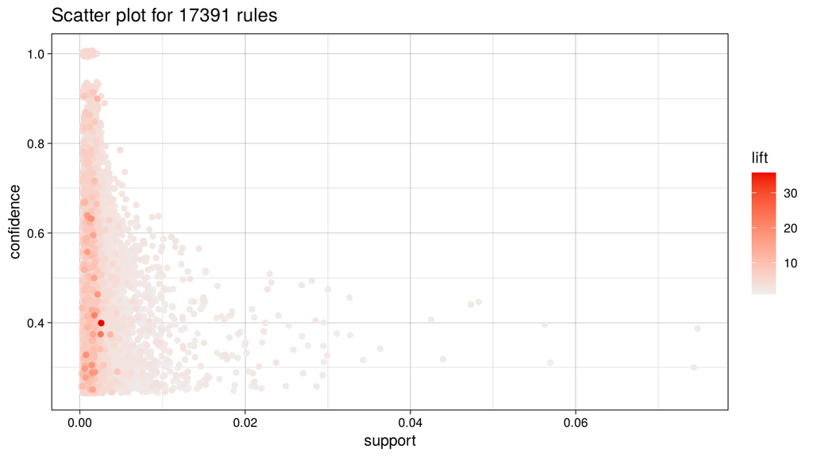

```r
plot(rules)                                       # support vs confidence, shaded by lift
```

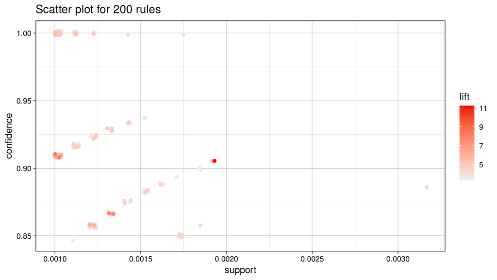

```r
plot(sort(rules, by = "confidence")[1:200])
```

`plot()` for rules comes from **arulesViz**. Without `library(arulesViz)` loaded, `plot(rules)` fails, so the sheet’s order (plot first, install arulesViz afterwards) needs swapping: load it first.

## B11. arulesViz graphs

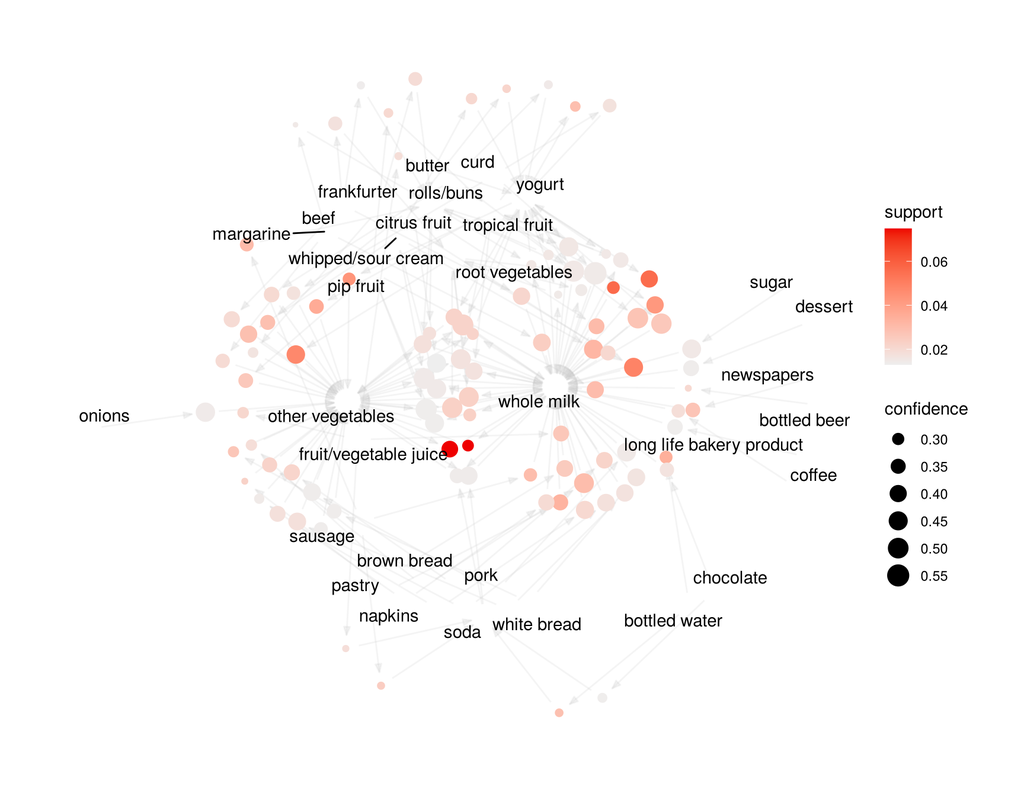

```r
# With all 17,391 rules arulesViz only draws the best 100 (by lift), with a warning
plot(rules, method = "graph", measure = "confidence", shading = "support")
```

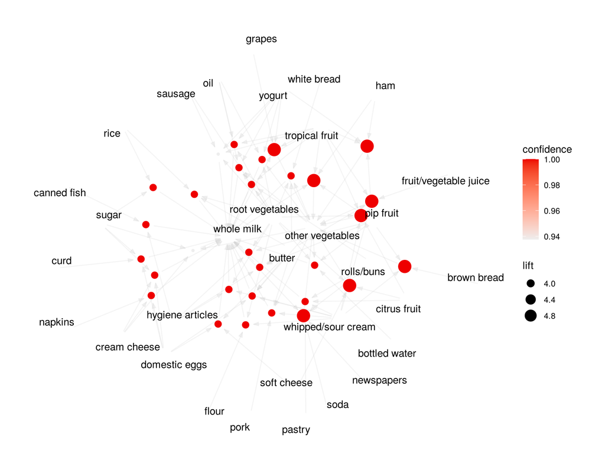

```r
plot(sort(rules, by = "confidence")[1:30], method = "graph", measure = "lift", shading = "confidence")
```

Circles are rules; arrows point from LHS items into a rule and from the rule to its RHS item. Circle size shows the measure, colour the shading. Nearly all arrows end at whole milk or other vegetables.

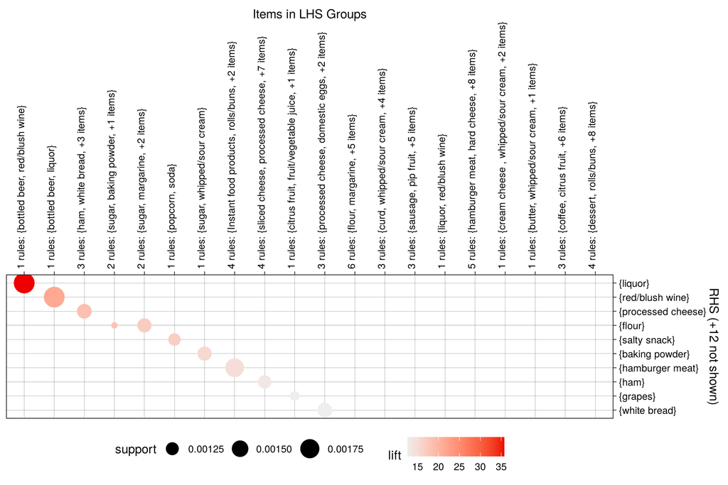

```r
plot(sort(rules, by = "lift")[1:50], method = "grouped")    # LHS groups vs RHS items
```

# Part C: Extra practice

## C1. Your own data with `read.transactions()`

```r
# Write a small basket file: one transaction per line, items separated by commas
tmp <- tempfile(fileext = ".csv")
writeLines(c("bread,milk,eggs", "bread,butter", "milk,nappies,beer", "bread,milk,butter"), tmp)
myT <- read.transactions(tmp, format = "basket", sep = ",")
inspect(myT)
```

```
##     items
## [1] {bread, eggs, milk}
## [2] {bread, butter}
## [3] {beer, milk, nappies}
## [4] {bread, butter, milk}
```

## C2. Classify some rules

```r
top <- sort(rules[!is.redundant(rules)], by = "lift")[1:8]
inspect(top)
```

```
##     lhs                                rhs                support
## [1] {bottled beer, red/blush wine}  => {liquor}           0.001931876
## [2] {ham, white bread}              => {processed cheese} 0.001931876
## [3] {bottled beer, liquor}          => {red/blush wine}   0.001931876
## [4] {Instant food products, soda}   => {hamburger meat}   0.001220132
## [5] {curd, sugar}                   => {flour}            0.001118454
## [6] {sugar, baking powder}          => {flour}            0.001016777
## [7] {processed cheese, white bread} => {ham}              0.001931876
## [8] {ham, fruit/vegetable juice}    => {processed cheese} 0.001118454
##     confidence coverage    lift     count
## [1] 0.3958333  0.004880529 35.71579 19
## [2] 0.3800000  0.005083884 22.92822 19
## [3] 0.4130435  0.004677173 21.49356 19
## [4] 0.6315789  0.001931876 18.99565 12
## [5] 0.3235294  0.003457041 18.60767 11
## [6] 0.3125000  0.003253686 17.97332 10
## [7] 0.4634146  0.004168785 17.80345 19
## [8] 0.2894737  0.003863752 17.46610 11
```

Discussion (Lantz’s three categories):

- **Trivial**: {bottled beer, red/blush wine} ⇒ {liquor}: alcohol is bought together; no surprise.
- **Actionable**: {herbs} ⇒ {root vegetables} (lift ≈ 4.0, 69 baskets): cooking ingredients; place together or bundle a recipe promotion.
- **Inexplicable**: a rule such as {Instant food products, soda} ⇒ {hamburger meat} could be a promotion that month, a single large customer, or chance among thousands of rules. Investigate before acting.

# Summary

| Task | R |
| --- | --- |
| Load | `data("Groceries")`, `read.transactions(file, format = "basket", sep = ",")` |
| Explore | `summary()`, `itemFrequency()`, `itemFrequencyPlot(topN, support)`, `image()` |
| Mine | `apriori(data, parameter = list(support, confidence, minlen))` |
| Inspect | `inspect(rules[1:20])`, `quality(rules)`, `size(rules)` |
| Rank and filter | `sort(rules, by = "lift")`, `subset(rules, rhs %in% "x" & lift > 3)`, `is.redundant()` |
| Lift by hand | `confidence / itemFrequency(data)[rhs]` |
| Plot | `library(arulesViz)`; `plot(rules)`, `method = "graph"`, `method = "grouped"` |